# Merits

# Disadvantages

1. its convergebce is not guranteed
2. Division by zero problems can occur.
3. root jumping might take place there by not getting intended solution.
4. in case of multiple roots , the method converges slowly

# Algorithm

```python
from math import sin
def secant(fn,x1,x2,tol,maxiter): # def secant
    for i in range(maxiter):  #startv itteration to maxiter
        xnew  = x2 - (x2-x1)/(fn(x2)-fn(x1))*fn(x2) #finding root by secant formula
        if abs(xnew-x2) < tol: # iff error less than tolertance
            break  # than break
        else:  # if not than go to else statement
            x1 = x2 #x1 is replace by x2
            x2 = xnew #xnew is replace by x1
    else:  # if not than go to else statement
        print('warning: Maximum number of iterations is reached')
    return xnew, i

f = lambda x: 2*x**2 - 5*x + 3 # given func

x1 = float(input('enter x1: ')) # input 1
x2 = float(input('enter x2: ')) #input 2

r, n = secant(f,x1,x2,1.0e-6,100) #def root and no itteration

print('Root = %f at %d iterations'%(r,n)) #print  root and no itteration
```

[output not shown]

# Graph

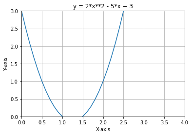

```python
import matplotlib.pyplot as plt
import numpy as np

x = np.arange(-1000, 1000, 0.1) # x axis from -1000 to 999.9
y = 2*x**2 - 5*x + 3         # y axis corresponding to 2*x**2 - 5*x + 3

plt.plot(x, y) # plot the graph
plt.xlim(-0.0001, 4.0000) # set x axis limit
plt.ylim(-0.0001, 3.0000) # set y axis limit
plt.xlabel('X-axis') # label the x axis
plt.ylabel('Y-axis') # label the y axis
plt.title('y = 2*x**2 - 5*x + 3') # add title to the graph
plt.grid(True) # add grid lines
plt.show() # show the graph
```

# Newton Raphson Method

The Newton-Raphson method is a way to quickly find a good approximation for the root of a real-valued function f ( x ) = 0 f(x) = 0 f(x)=0. It uses the idea that a continuous and differentiable function can be approximated by a straight line tangent to it.

# Advantages

1. One of the fastest methods which converges to root quickly.
2. Converges on the root quadraticallyi.e rate of convergence
3. As we go near to root, number of significant digits approximately doubles with each step.

# Disadvantages

1. It's convergence is not guaranteed.
2. Division by zero problems can occur.
3. Root jumping might take place thereby not getting intended solution.
4. Inflection point issue might occur.
5. Symbolic derivative is required.
6. In case of multiple roots, this method converges slowly.

```python
from math import sin
def newton(fn,dfn,x,tol,maxiter): # def newton raphson
    for i in range(maxiter):# using for loop to start itteration till mixter
        xnew = x - fn(x)/dfn(x) #newton raphson formula
        if abs(xnew-x)<tol:    #error less than tolertance
            break #than break
        x = xnew #than x is new
    return xnew, i

y = lambda x: 2*x**3-9.5*x+7.5 #function
dy = lambda x : 6*x**2-9.5  #derivation of function

x, n = newton(y, dy, 5, 0.0001, 100) #calliong the function
print('the root is %.3f at %d iterations.'%(x,n))
```

[output not shown]

```python
def secant_method(f, x0, x1, tol=1e-6, max_iter=100):
    """
    Implementation of the Secant method for finding roots of a function.

    Parameters:
    f (function): The function for which to find a root.
    x0 (float): The first initial point.
    x1 (float): The second initial point.
    tol (float, optional): The tolerance for the stopping criterion. Defaults to 1e-6.
    max_iter (int, optional): The maximum number of iterations. Defaults to 100.

    Returns:
    float: The root of the function.
    """
    i = 0
    while i < max_iter:
        x2 = x1 - f(x1) * (x1 - x0) / (f(x1) - f(x0))
        if abs(x2 - x1) < tol:
            return x2
        x0, x1 = x1, x2
        i += 1
    return None

# Example usage:
f = lambda x: x**3 - x - 1
x0 = int(input("Enter first initial point: "))
x1 = int(input("Enter second initial point: "))
root = secant_method(f, x0, x1)
print("The root of the function is:", root)
```

[output not shown]